# Project: Investigate a Dataset - [European Soccer Database]

### Research Question 4: Who is the highest rated player?

We will answer this using the players table

```python
# modify table and subset for top_10 players
players_by_rating = players.groupby("player_name")[["overall_rating"]].mean().sort_values(by="overall_rating", ascending=False)
top_10_players = players_by_rating.iloc[:10].sort_values(by="overall_rating").reset_index()
top_10_players
```

|  | player_name | overall_rating |
| --- | --- | --- |
| 0 | Philipp Lahm | 86.733333 |
| 1 | Iker Casillas | 86.954545 |
| 2 | Wayne Rooney | 87.222222 |
| 3 | Xavi Hernandez | 87.636364 |
| 4 | Arjen Robben | 87.840000 |
| 5 | Zlatan Ibrahimovic | 88.285714 |
| 6 | Andres Iniesta | 88.320000 |
| 7 | Franck Ribery | 88.458333 |
| 8 | Cristiano Ronaldo | 91.280000 |
| 9 | Lionel Messi | 92.192308 |

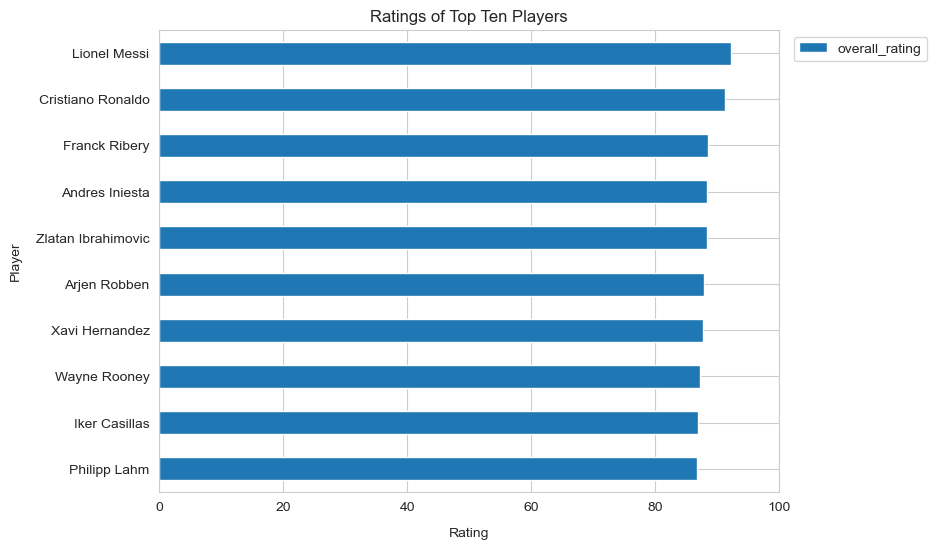

```python
# visualize ratings
sns.set_style("whitegrid")
top_10_players.plot("player_name", "overall_rating", kind="barh", figsize=(8, 6))
plt.xlabel("Rating", labelpad=10)
plt.ylabel("Player", labelpad=10)
plt.title("Ratings of Top Ten Players")
plt.legend(loc="upper right", bbox_to_anchor=(1.25, 1))
plt.xlim([0, 100]);
```

### Research Question 5: What attributes affect player's rating?

We will answer this using the players table. We will consider the relationship between player's rating and some attributes using scatter plots.

```python
# view correlation of rating with players attributes
players.corr()[["overall_rating"]]
```

|  | overall_rating |
| --- | --- |
| player_api_id | -0.328315 |
| overall_rating | 1.000000 |
| potential | 0.765435 |
| crossing | 0.357320 |
| finishing | 0.330079 |
| heading_accuracy | 0.313324 |
| short_passing | 0.458243 |
| volleys | 0.361739 |
| dribbling | 0.354191 |
| curve | 0.357566 |
| free_kick_accuracy | 0.349800 |
| long_passing | 0.434525 |
| ball_control | 0.443991 |
| acceleration | 0.243998 |
| sprint_speed | 0.253048 |
| agility | 0.239963 |
| reactions | 0.771856 |
| balance | 0.160211 |
| shot_power | 0.428053 |
| jumping | 0.258978 |
| stamina | 0.325606 |
| strength | 0.315684 |
| long_shots | 0.392668 |
| aggression | 0.322782 |
| interceptions | 0.249094 |
| positioning | 0.368978 |
| vision | 0.431493 |
| penalties | 0.392715 |
| marking | 0.132185 |
| standing_tackle | 0.163986 |
| sliding_tackle | 0.128054 |
| gk_diving | 0.027675 |
| gk_handling | 0.006717 |
| gk_kicking | 0.028799 |
| gk_positioning | 0.008029 |
| gk_reflexes | 0.007804 |

```python
# group players table by player and get average of attributes to be considered for analysis
attributes_to_consider = ["overall_rating", "sprint_speed", "acceleration", "ball_control", "balance", "free_kick_accuracy",
                          "potential", "long_shots", "aggression", "stamina", "vision", "reactions"]

players_attributes = players.groupby("player_name")[attributes_to_consider].mean()
players_attributes.head()
```

| player_name | overall_rating | sprint_speed | acceleration | ball_control | balance | free_kick_accuracy | potential | long_shots | aggression | stamina | vision | reactions |
| --- | --- | --- | --- | --- | --- | --- | --- | --- | --- | --- | --- | --- |
| Aaron Appindangoye | 63.600000 | 64.000000 | 60.000000 | 48.600000 | 65.000000 | 38.600000 | 67.600000 | 34.600000 | 65.800000 | 54.000000 | 53.600000 | 46.600000 |
| Aaron Cresswell | 66.969697 | 74.939394 | 76.000000 | 61.787879 | 84.727273 | 62.121212 | 74.484848 | 54.121212 | 65.060606 | 72.878788 | 57.454545 | 67.848485 |
| Aaron Doran | 67.000000 | 77.500000 | 75.538462 | 68.615385 | 80.730769 | 55.615385 | 74.192308 | 58.038462 | 59.115385 | 70.923077 | 69.384615 | 50.346154 |
| Aaron Galindo | 69.086957 | 52.826087 | 50.217391 | 63.173913 | 44.086957 | 40.391304 | 70.782609 | 31.304348 | 69.304348 | 55.434783 | 53.782609 | 58.217391 |
| Aaron Hughes | 73.240000 | 54.080000 | 51.120000 | 60.160000 | 64.160000 | 26.360000 | 74.680000 | 24.280000 | 69.680000 | 66.480000 | 46.480000 | 69.400000 |

```python
# define function to plot ratings versus attributes
def plot_attribute(column2):
    players_attributes.plot("overall_rating", column2, kind="scatter", figsize=(8, 8))
    plt.xlabel("Rating", labelpad=10)
    plt.ylabel(column2, labelpad=10)
    plt.title("Relationship between player's rating and " + column2)
    return plt.show()
```

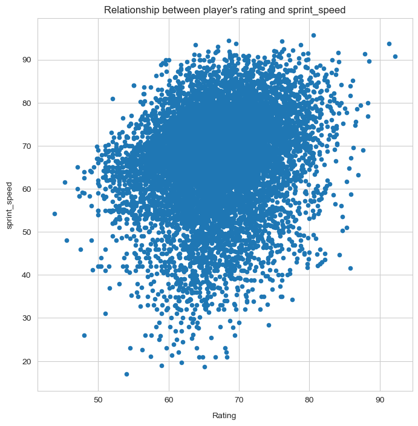

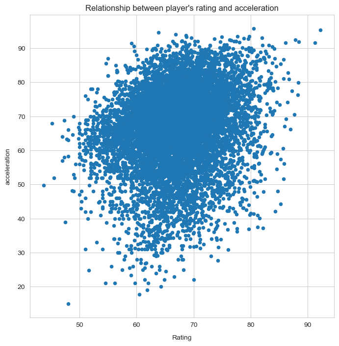

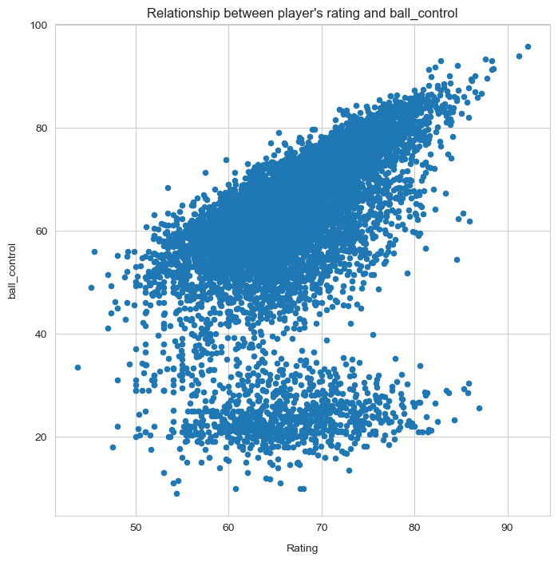

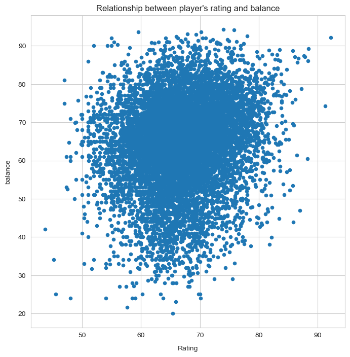

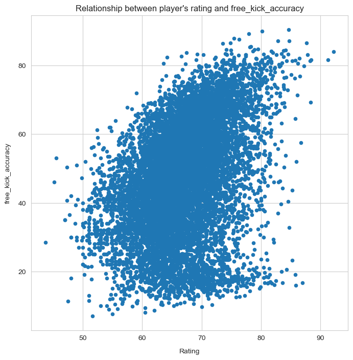

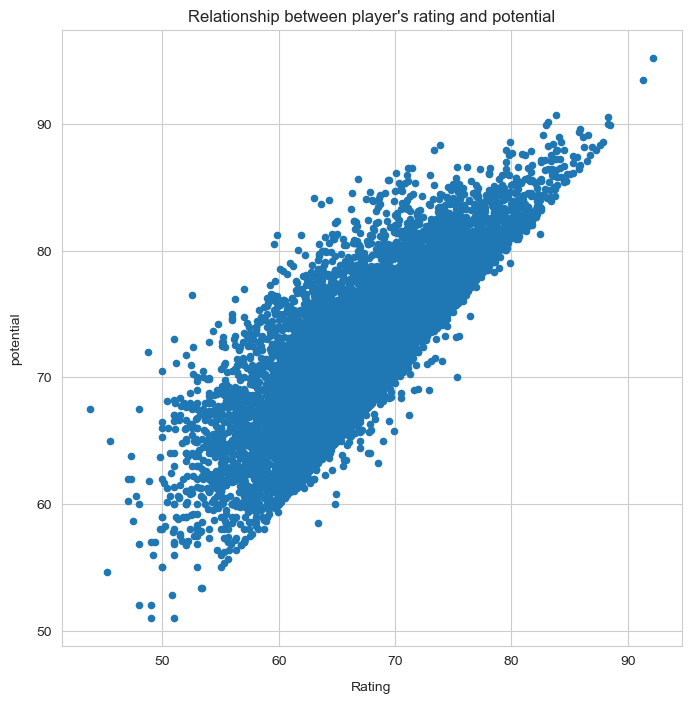

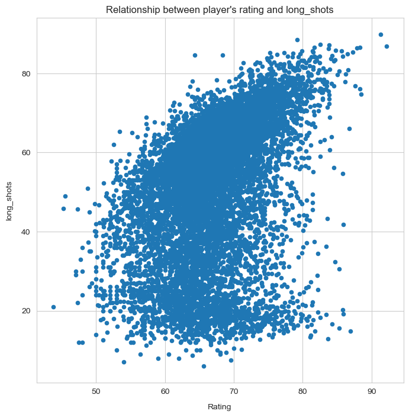

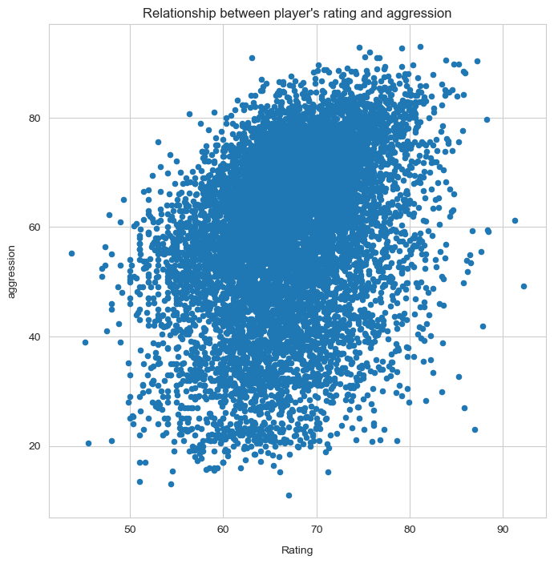

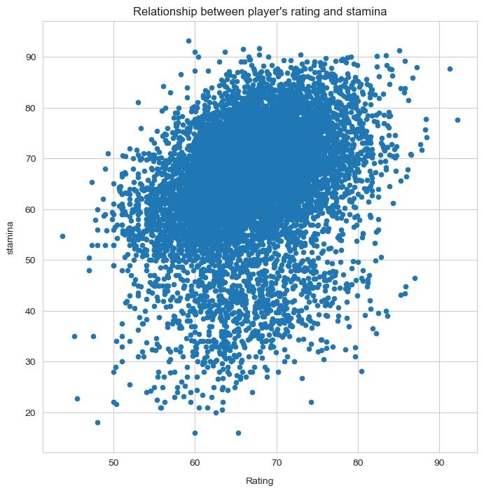

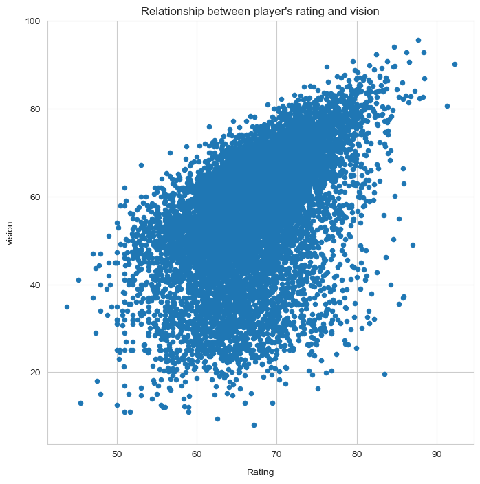

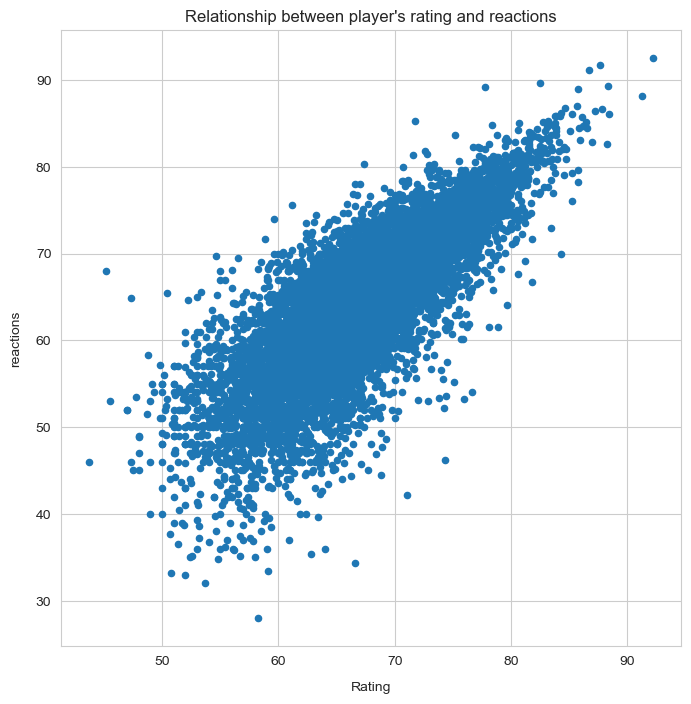

```python
# plot rating versus attributes
for attribute in attributes_to_consider[1:]:
    plot_attribute(attribute)
```

## Conclusions

> **Limitations**:
> 1. This data is a large one with several tables that are linked. There are a host of questions one can ask with this dataset but due to my limited understanding of some concepts and columns, like the betting odds, I have kept my analysis basic.
> 2. Looking at the relationship between the overall rating and only a few attributes is not enough to generalise on what attributes affect player's rating? Ideally, all attributes should be considered.